# A Primer on Mandatory disclosure data

2017-12-01

## 0.1 tl;dr

This is a report on payment data from mandatory disclosure reports that have been processed by the Research and data team at [NRGI](https://resourcegovernance.org/). It covers basic information on the coverage of mandatory disclosures that have been processed by the team.

## 0.2 Summary

1. What is the RP converage by commodity?
2. Compare payout across years for different project types (oil and gas, mining and corporate)

## 0.3 Data descriptives

The first series of charts give an overview of the coverage in terms of number of reports and amounts disclosed.

### 0.3.1 Mandatory Disclosures by Year

First lets look at the number of disclosures that have been across all the years in the data and compare the total payments.

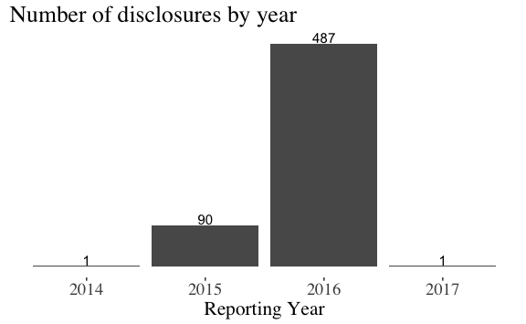

```r
sourceData %>%
    group_by(reportYear) %>%
    summarise(nSources = n_distinct(sourceID)) %>%
    ggplot(., aes(x = reportYear, y = nSources)) +
    geom_bar(stat = "identity") +
    geom_text(aes(label = nSources), vjust = -0.1, position = position_dodge(width = 0.9), size = 4) +
    labs(title = "Number of disclosures by year",
         x = "Reporting Year") +
    theme_tufte() +
    theme(
        axis.text.y = element_blank(),
        axis.ticks.y = element_blank(),
        axis.title.y = element_blank(),
        title = element_text(size = 16),
        axis.text.x = element_text(size = 14)
    )
```

The chart below breaks these down by the reporting jurisdictions. As can be seen the spike spike of reports in 2016 are because of the mandatory disclosures through the Extractive Sector Transparency Measures Act ([ESTMA](http://laws-lois.justice.gc.ca/eng/acts/E-22.7/page-1.html)). For a more specific information on sources disclosed in different jurisdictions, please visit this page on [resourceproject.org](http://resourceprojects.org/).

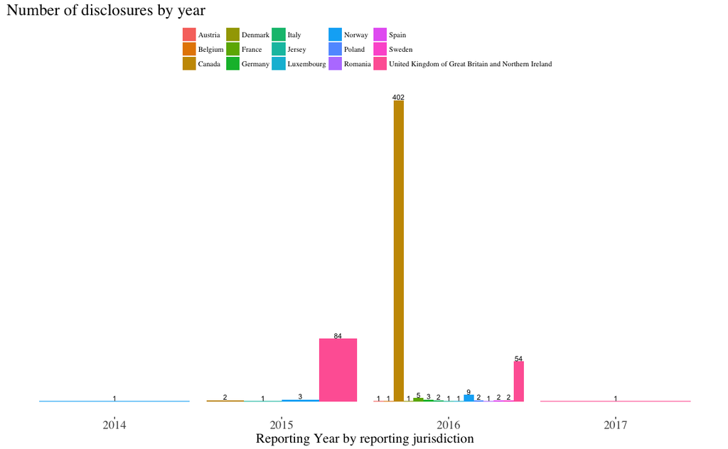

```r
sourceData %>%
    group_by(reportYear, reportingCountry) %>%
    summarise(nSources = n_distinct(sourceID)) %>%
    ggplot(., aes(x = reportYear, y = nSources, fill = reportingCountry)) +
    geom_bar(stat = "identity", position = "dodge") +
    geom_text(aes(label = nSources), vjust = -0.1, position = position_dodge(width = 0.9), size = 3) +
    labs(title = "Number of disclosures by year",
         x = "Reporting Year by reporting jurisdiction") +
    theme_tufte() +
    theme(
        legend.position = "top",
        legend.title = element_blank(),
        axis.text.y = element_blank(),
        axis.ticks.y = element_blank(),
        axis.title.y = element_blank(),
        title = element_text(size = 16),
        axis.text.x = element_text(size = 14)
    )
```

The next chart shows the total payment amounts by year.

**Note :** The large payouts from 2014 are from a single [Statoil disclosure from that year](https://www.statoil.com/content/dam/statoil/documents/annual-reports/2014/statoil-payments-to-governments-2014.pdf)

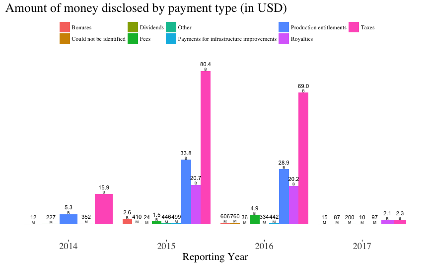

```r
projectData %>%
    group_by(reportYear, paymentType) %>%
    summarise(totPay = sum(projectPayment, na.rm = T), nSources = n_distinct(sourceID)) %>%
    ggplot(., aes(x = reportYear, y = totPay, fill = paymentType)) +
    geom_bar(stat = "identity", position = "dodge") +
    scale_y_continuous(expand = c(0.1, 0)) +
    geom_text(aes(label = if_else(totPay < 1e9, format(round(totPay / 1e6, 0), trim = TRUE), format(round(totPay / 1e9, 1), trim = TRUE))), vjust = -1.25, position = position_dodge(width = 0.9), size = 3) +
    geom_text(aes(label = if_else(totPay < 1e9, "M", "B")), vjust = -.15, position = position_dodge(width = 0.9), size = 2) +
    labs(title = "Amount of money disclosed by payment type (in USD)",
         x = "Reporting Year") +
    theme_tufte() +
    theme(
        axis.text.y = element_blank(),
        axis.ticks.y = element_blank(),
        axis.title.y = element_blank(),
        title = element_text(size = 16),
        legend.position = "top",
        legend.title = element_blank(),
        axis.text.x = element_text(size = 14)
    )
```

The chart below shows the companies that paid more than 5 billion USD each year through mandatory disclosures. Interestingly there a few companies that seem to have a great deal of fluctuations in total amounts paid across different years. For instance, the total payments made by Statoil goes down from 21.7 Billion USD in 2014 to 6.5 Billion USD in 2016. This might be partly explained by the drop in oil prices across these years, however, the Russian companies don’t seem to have been affected by this as much in comparison.

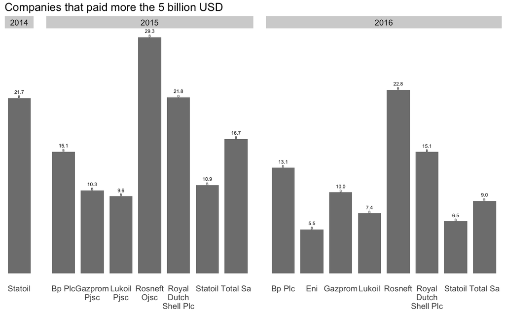

```r
projectData %>%
    group_by(reportingCompany, reportYear) %>%
    filter(sum(projectPayment, na.rm = T) > 5e9) %>% #3filter if total payment for that year was greater than 10 billion
    summarise(totPay = sum(projectPayment)) %>%
    ggplot(., aes(x = reportingCompany, y = totPay)) +
    geom_bar(stat = "identity", position = "dodge", alpha = 0.8, width = 0.8) +
    scale_y_continuous(expand = c(0.038, 0)) +
    geom_text(aes(label = if_else(totPay < 1e9, format(round(totPay / 1e6, 0), trim = TRUE), format(round(totPay / 1e9, 1), trim = TRUE))), vjust = -1.25, position = position_dodge(width = 0.9), size = 3) +
    geom_text(aes(label = if_else(totPay < 1e9, "M", "B")), vjust = -.15, position = position_dodge(width = 0.9), size = 2) +
    scale_x_discrete(labels = function (paymentType) str_wrap(paymentType, width = 10)) +
    facet_grid(~reportYear, space = "free_x", scales = "free_x") +
    labs(title = "Companies that paid more the 5 billion USD") +
    theme_bw() +
    theme(
        strip.text.x = element_text(size = 14),
        axis.text.y = element_blank(),
        axis.line = element_blank(),
        axis.ticks = element_blank(),
        axis.title = element_blank(),
        title = element_text(size = 16),
        legend.position = "top",
        legend.title = element_blank(),
        axis.text.x = element_text(size = 14),
        panel.grid = element_blank(),
        panel.border=element_blank(),
        panel.spacing.x = unit(1.5, "lines"),
        strip.background = element_rect(fill = "lightgrey", linetype = 0)
    )
```

Lets also look at the top recipients of resource payments.

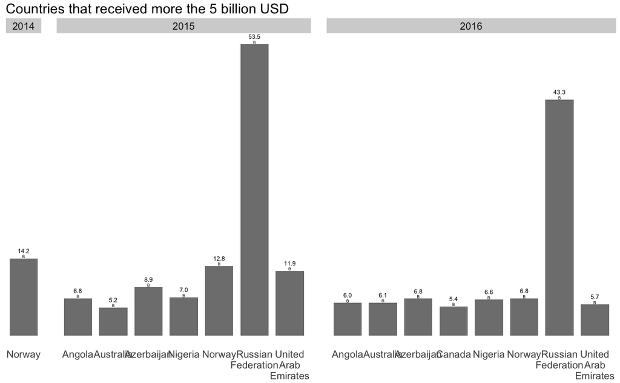

```r
projectData %>%
    group_by(projectCountry, reportYear) %>%
    filter(sum(projectPayment, na.rm = T) > 5e9) %>% #3filter if total payment for that year was greater than 10 billion
    summarise(totPay = sum(projectPayment)) %>%
    ggplot(., aes(x = projectCountry, y = totPay)) +
    geom_bar(stat = "identity", position = "dodge", alpha = 0.8, width = 0.8) +
    scale_y_continuous(expand = c(0.038, 0)) +
    geom_text(aes(label = if_else(totPay < 1e9, format(round(totPay / 1e6, 0), trim = TRUE), format(round(totPay / 1e9, 1), trim = TRUE))), vjust = -1.25, position = position_dodge(width = 0.9), size = 3) +
    geom_text(aes(label = if_else(totPay < 1e9, "M", "B")), vjust = -.15, position = position_dodge(width = 0.9), size = 2) +
    scale_x_discrete(labels = function (paymentType) str_wrap(paymentType, width = 9)) +
    facet_grid(~reportYear, space = "free_x", scales = "free_x") +
    labs(title = "Countries that received more the 5 billion USD") +
    theme_bw() +
    theme(
        strip.text.x = element_text(size = 14),
        axis.text.y = element_blank(),
        axis.line = element_blank(),
        axis.ticks = element_blank(),
        axis.title = element_blank(),
        title = element_text(size = 16),
        legend.position = "top",
        legend.title = element_blank(),
        axis.text.x = element_text(size = 14),
        panel.grid = element_blank(),
        panel.border=element_blank(),
        panel.spacing.x = unit(1.5, "lines"),
        strip.background = element_rect(fill = "lightgrey", linetype = 0)
    )
```

```r
NA
```